# Business Analytics of New York HMDA data using R

Adam Georgie and Anna

Winter, 2025

## Final Project Questions

### Data Loading and Create necessary variables (5 points)

```r
library(dplyr)
hmda <- read.csv("~/R stuff/nyhousingdata.csv")
set.seed(2081438)
indata <- hmda %>%
mutate(race = case_when(
derived_race == "Asian" ~ "Asian",
derived_race == "White" ~ "White",
derived_race == "Black or African American" ~ "Black", TRUE ~ "Others"),
sex = as.factor(derived_sex),
age = as.factor(applicant_age),
denial = ifelse(action_taken == 3,1,0 ),
loan_type = as.factor(loan_type),
purchaser_type = as.factor(purchaser_type), loan_amount = log(as.numeric(loan_amount)),
loan_term = as.numeric(loan_term),
property_value = log(as.numeric(property_value)), occupancy_type = as.factor(occupancy_type), area_income = log(ffiec_msa_md_median_family_income), area_minority = tract_minority_population_percent , income = log(income)
) %>%
filter(action_taken== 1 | action_taken == 3,
loan_type == 1 , loan_purpose == 1, property_value > 0 ,
loan_amount > 0 , property_value > loan_amount , area_income > 0 ,
total_units == "1",
income > 0 ) %>%
select(denial, race, sex, age, purchaser_type, income,
loan_amount, loan_term, property_value, occupancy_type, area_income, area_minority)
colSums(is.na(indata))
```

```
##         denial           race            sex            age purchaser_type
##              0              0              0              0              0
##         income    loan_amount      loan_term property_value occupancy_type
##              0              0            142              0              0
##    area_income  area_minority
##              0              0
```

```r
indata<-indata[complete.cases(indata),]
```

### Descriptive Analytics (10 points)

1. **Provide a summary of the dataset and describe key patterns observed in the data.**
   - Discuss how these patterns may relate to business decisions in the mortgage industry.

```r
summary(indata)
```

```
##      denial           race                          sex             age
##  Min.   :0.0000   Length:87201       Female           :20549   25-34  :28736
##  1st Qu.:0.0000   Class :character   Joint            :33693   35-44  :25555
##  Median :0.0000   Mode  :character   Male             :27964   45-54  :14609
##  Mean   :0.1073                      Sex Not Available: 4995   55-64  : 9763
##  3rd Qu.:0.0000                                                65-74  : 4130
##  Max.   :1.0000                                                <25    : 3380
##                                                                (Other): 1028
##  purchaser_type      income         loan_amount       loan_term
##  0      :38537   Min.   : 0.6931   Min.   : 8.517   Min.   :  6.0
##  3      :15362   1st Qu.: 4.4773   1st Qu.:12.181   1st Qu.:360.0
##  1      :14351   Median : 4.9053   Median :12.692   Median :360.0
##  71     : 6880   Mean   : 4.9744   Mean   :12.682   Mean   :348.5
##  6      : 6703   3rd Qu.: 5.3799   3rd Qu.:13.190   3rd Qu.:360.0
##  8      : 3008   Max.   :11.9303   Max.   :16.717   Max.   :480.0
##  (Other): 2360
##  property_value   occupancy_type  area_income    area_minority
##  Min.   : 9.616   1:79856        Min.   :11.31   Min.   :  0.00
##  1st Qu.:12.449   2: 3561        1st Qu.:11.49   1st Qu.: 13.80
##  Median :13.028   3: 3784        Median :11.51   Median : 24.92
##  Mean   :13.012                  Mean   :11.59   Mean   : 32.33
##  3rd Qu.:13.494                  3rd Qu.:11.69   3rd Qu.: 42.97
##  Max.   :20.723                  Max.   :11.96   Max.   :100.00
##
```

#Using the summary function, those in the morgage industry would be interested in mean income, and property value. Lenders would likely be weary of desparities between average income and property_value, potentially denying those in the first quartile of income seeking proprty in the third quartile of value

2. **Create graphical representations (using `ggplot2`) to explore relationships between loan denial vs. gender, race, and income area (high, mid, and lower-income areas).**
   - Define income area by high, mid, and low income areas using area_income.
   - Clearly interpret and discuss the findings from these visualizations.
   - Explain how financial institutions might use these insights in their lending policies and risk assessments.

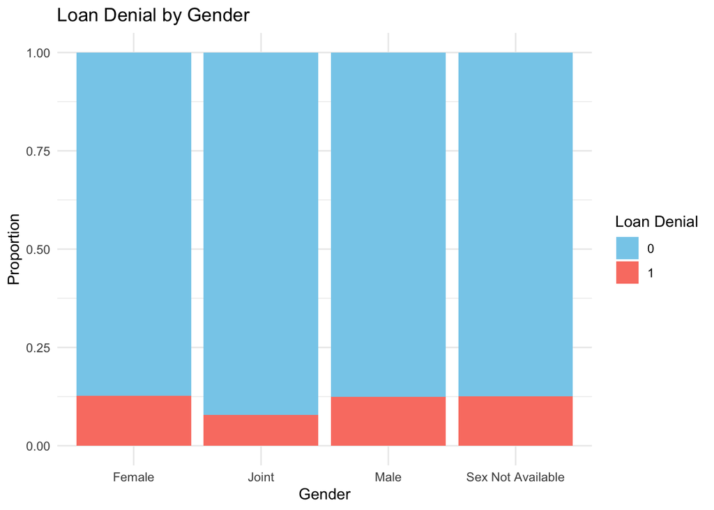

```r
library(ggplot2)

indata<- indata %>%
  mutate(area_income = case_when(
    area_income >= quantile(area_income, .67) ~ "High",
    area_income >= quantile(area_income, .33)  & area_income < quantile (area_income, .67) ~ "Mid", TRUE~"Low"
    ))

# Plot 1: Loan denial vs. gender
ggplot(indata, aes(x = sex, fill = factor(denial))) +
  geom_bar(position = "fill") +
  labs(x = "Gender", y = "Proportion", fill = "Loan Denial") +
  theme_minimal() +
  ggtitle("Loan Denial by Gender") +
  scale_fill_manual(values = c("skyblue", "salmon"))
```

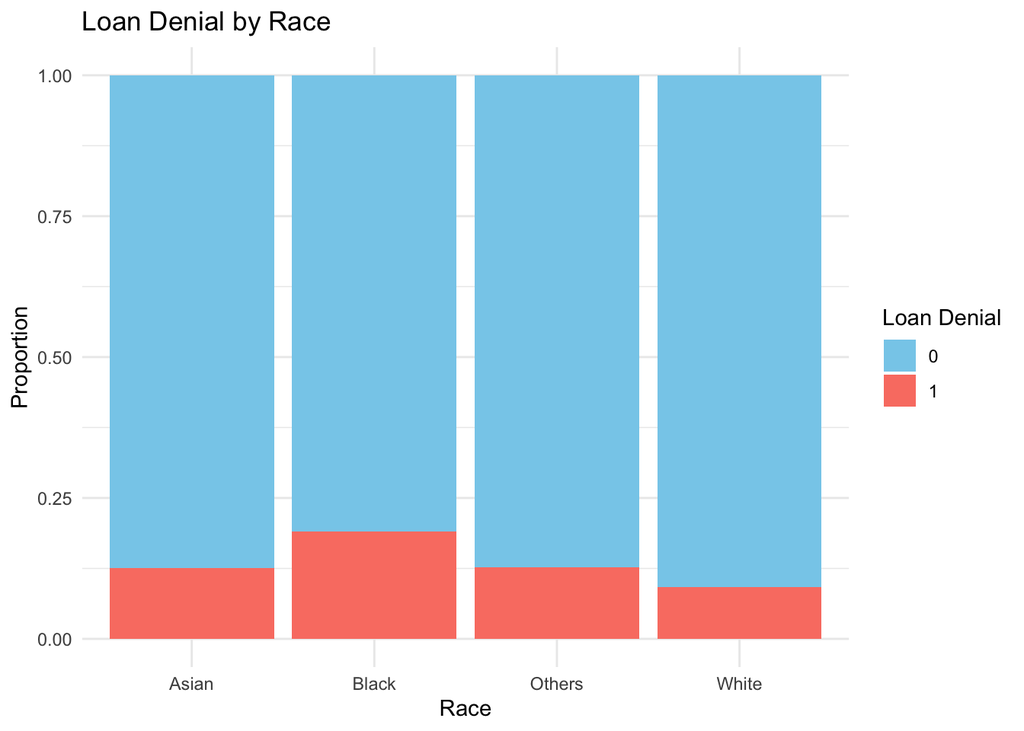

```r
# Plot 2: Loan denial vs. race
ggplot(indata, aes(x = race, fill = factor(denial))) +
  geom_bar(position = "fill") +
  labs(x = "Race", y = "Proportion", fill = "Loan Denial") +
  theme_minimal() +
  ggtitle("Loan Denial by Race") +
  scale_fill_manual(values = c("skyblue", "salmon"))
```

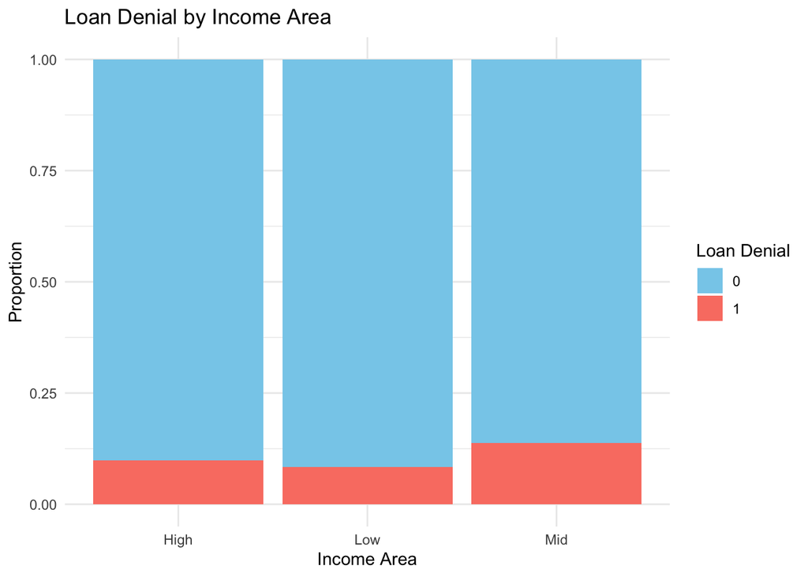

```r
# Plot 3: Loan denial vs. income area
ggplot(indata, aes(x = area_income, fill = factor(denial))) +
  geom_bar(position = "fill") +
  labs(x = "Income Area", y = "Proportion", fill = "Loan Denial") +
  theme_minimal() +
  ggtitle("Loan Denial by Income Area") +
  scale_fill_manual(values = c("skyblue", "salmon"))
```

3. **Conduct hypothesis tests to analyze differences in loan denial rates across groups in 2.**
   - State the null and alternative hypotheses.
   - Report the results.
   - Explain the implications of the findings in the context of mortgage lending fairness, regulatory compliance, and business strategy.

```r
library(car)
```

```r
library(ggplot2)

#Gender
#Ho: Loan denial rates are independent of gender  Ha: Gender significantly impacts loan denial rates
table_gender_denial <- table(indata$sex, indata$denial)
chisq_gender_result <- chisq.test(table_gender_denial)
chisq_gender_result
```

```
##
##  Pearson's Chi-squared test
##
## data:  table_gender_denial
## X-squared = 468.45, df = 3, p-value < 2.2e-16
```

```r
#Race
#Ho: Loan denial rates are independent of Race  Ha: Race significantly impacts loan denial rates
table_race_denial <- table(indata$race, indata$denial)
chisq_race_result <- chisq.test(table_race_denial)
chisq_race_result
```

```
##
##  Pearson's Chi-squared test
##
## data:  table_race_denial
## X-squared = 573.98, df = 3, p-value < 2.2e-16
```

```r
#Income
#Ho: Loan denial rates are independent of Income  Ha: Race significantly impacts loan denial rates
table_income_area_denial <- table(indata$area_income, indata$denial)
chisq_income_area_result <- chisq.test(table_income_area_denial)
chisq_income_area_result
```

```
##
##  Pearson's Chi-squared test
##
## data:  table_income_area_denial
## X-squared = 485.53, df = 2, p-value < 2.2e-16
```

4. **Perform correlation analysis:**
   - Analyze the correlation between loan amounts and other continuous variables.
   - Analyze the correlation between loan denial and other relevant variables.

```r
indata %>%
  select_if(is.numeric) %>%
summarise(across(everything(), ~ cor(.x, loan_amount, use = "complete.obs")))
```

```
##        denial    income loan_amount loan_term property_value area_minority
## 1 -0.08883598 0.7065659           1 0.2996686      0.8918388     0.1071656
```

```r
chisq.test(table(indata$race, indata$denial))
```

```
##
##  Pearson's Chi-squared test
##
## data:  table(indata$race, indata$denial)
## X-squared = 573.98, df = 3, p-value < 2.2e-16
```

```r
chisq.test(table(indata$sex, indata$denial))
```

```
##
##  Pearson's Chi-squared test
##
## data:  table(indata$sex, indata$denial)
## X-squared = 468.45, df = 3, p-value < 2.2e-16
```

```r
chisq.test(table(indata$occupancy_type, indata$denial))
```

```
##
##  Pearson's Chi-squared test
##
## data:  table(indata$occupancy_type, indata$denial)
## X-squared = 71.553, df = 2, p-value = 2.901e-16
```